# Introducción a Python y gráficos

[figure not shown]

## Contenidos

- Introducción a conceptos básicos de *Python*
- Librerías a usar:
- Tipos de gráficos
- Dar formato a gráfico

# Python

Python es un lenguaje de programación interpretado multiparadigma.

- Creado a fines de los 80 por Guido von Rossum.
- El nombre del lenguaje proviene de la afición de su creador por los humoristas británicos Monty Python.

[figure not shown]

# Características

- Facilidad de escritura y lectura$^1$.
- Compatibilidad en en múltiples sistemas operativos (portabilidad).
- Extensibilidad.
- Código abierto.

*1: Cuando está bien escrito*

```python
# Acá irían ejemplos básicos
```

# Tipos de datos en Python

```python
# Strings
"Instituto de Investigación y Desarrollo en Ingeniería de Procesos y Química Aplicada - IPQA"
# Números enteros
5
# Números flotantes
1.249
# Listas
[1, 2, 3, 4]
# Diccionarios
{
    "nombre": "Federico Benelli",
    "edad": 27,
    "cursos": ["Termodinámica y Comportamientos de Fases de Fluidos en Ingeniería",
               "Diseño de Software Científico"]
}
```

```
{'nombre': 'Federico Benelli',
 'edad': 27,
 'cursos': ['Termodinámica y Comportamientos de Fases de Fluidos en Ingeniería',
  'Diseño de Software Científico']}
```

# Operaciones

```python
# Suma/Resta
1 + 2
# Multiplicación
2*2
# Potencia
2**2
```

```
4
```

En todos los casos se respeta el orden de precedencia esperable de las operaciones matemáticas:

Paréntesis $\rightarrow$ Potencias $\rightarrow$ Productos $\rightarrow$ Sumas

# Comparaciones lógicas

```python
1 == 1    # Igualdad
2 != 1    # Desigualdad
1 < 2     # Menor a
2 > 1     # Mayor a
2 <= 1    # Menor o igual a
1 >= 1    # Mayor o igual a
```

```
True
```

# Cómo interperta Python estas operaciones?

```python
# Hacer ejemplos simples interactivos de operaciones y comparaciones,
# y hablar de variables
```

# Control de flujo de código

El flujo del código se controla mediante operadores condicionales

```
if, else y elif
```

Y mediante operadores iteradores

```
for, while
```

## Operadores condicionales

[figure not shown]

```python
# Ejemplo de flujo condicional
porcentaje_tesis = 50

if porcentaje_tesis < 50:
    print('Falta bastante...')

elif porcentaje_tesis <= 75:
    print('Falta un cachito...')

elif porcentaje_tesis < 100:
    print('Ya casi ya casi!')

else:
    print('Se terminó!!')
```

```
Falta un cachito...
```

## Operadores de iteración

Se pueden hacer flujos iterativos con los operadores:

```python
# Ejemplos
```

# Funciones

Para simplificar el código pueden definirse funciones, las cuales reciben un input (o no) y realizan operaciones.

Siempre devuelven un valor! De no especificarse devuelven un valor Nulo `NoneType`

Python posee por defecto funciones de utilidad

```
print()    # Imprime en pantalla el valor dado
abs()      # Valor absoluto
round()    # Redondeo de números flotantes
min()      # Valor mínimo de una lista
sorted()   # Ordena una lista
sum()      # Sumatoria de una lista
len()      # Largo de una lista
type()     # Tipo de variable
```

```python
# Acá se muestra como funcionan las funciones de manera práctica
```

## Definición de funciones

Además de las funciones predeterminadas de Python, se pueden definir todas las funciones que se deseen.

```python
def cuadratica(x, a, b, c):
    """Calcula un polinómio cuadrático en el valor x dado
    args:
    x     (float): Valor de x donde calcular
    a,b,c (float): Coeficientes cuadráticos

    returns:
    y     (float): Función cuadrática valuada en x"""

    y = a*x**2 + b*x + c
    return y
```

```python
cuadratica(1, 1, 2, 4)
```

```
7
```

```python
X = []
Y = []
a, b, c = 2, 4, 6
for x in range(10):

    # Valuar función en x y asignar a variable `y`
    y = cuadratica(x, a, b, c)

    # Concatenar valor de x a lista de Xs
    X.append(x)

    # Idem y
    Y.append(y)

    if y > 100:
        print('El valor de y superó 100!')
        print('y=', y)
        break

print(X)
print(Y)
```

```
El valor de y superó 100!
y= 102
[0, 1, 2, 3, 4, 5, 6]
[6, 12, 22, 36, 54, 76, 102]
```

# Librerías

Una de las características de Python es su extensibilidad por medio de librerías.

Las librerías son conjuntos de métodos, funciones, variables. Generadas para cumplir funciones particulares, en el ámbito científico destacan:

- `numpy`: Cálculo vectorial.
- `scipy`: Conjunto de librerías de uso científico, como estadística y cálculo matemático.
- `pandas`: Interpretación de datos.
- `matplotlib`: Generación de gráficos

## Evolución de desarrollo de librerías

[figure not shown]

# Generación de gráficos en Python

La variedad de gráficos que se pueden realizar en Python es superlativa.

Solo basta con entrar a la galería de ejemplos de [matplotlib](https://matplotlib.org/stable/gallery/index.html) para darse una idea de lo extenso que es. Y es una librería sola!

Además de `matplotlib` existen otras librerías que se utilizan para generar gráficos, como:

- `plotly`
- `seaborn`
- `bokeh`

Aquí se van a ver conceptos básicos de `matplotlib`

## Importación de librerías

En primera instancia, se importan librerías de interés.

```python
import matplotlib.pyplot as plt   # Gráficos
import pandas as pd               # Tratamiento de datos
```

```python
# Todo el código dentro de la presentación es interactivo
# la idea es mostrar primero el concepto básico y de ahí ir incrementando el detalle:
#   cambiar colores, agregar leyendas, escalas, múltiples datos, etc.
```

## Gráficos de línea

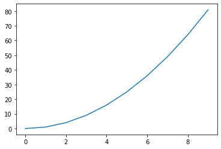

```python
x = []
for i in range(10):
    x.append(i)

y = [xi**2 for xi in x]

plt.plot(x,y)
plt.show()
```

## Gráficos de dispersión

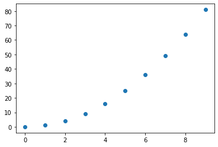

```python
plt.scatter(x,y)
plt.show()
```

## Barras

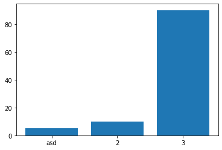

```python
x = ['asd', '2', '3']
y = [5, 10, 90]

plt.bar(x,y)
plt.show()
```

## Formato extra

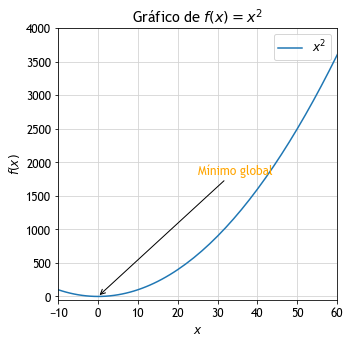

```python
x = []

for i in range(-100,100):
    x.append(i)

y = [xi**2 for xi in x]

y0 = 0
x0 = 0

plt.rcParams['font.family'] = 'Trebuchet MS'
plt.rcParams['font.size'] = 12

fig = plt.figure(figsize=(5,5))

plt.plot(x,y, label = '$x^2$')
plt.title('Gráfico de $f(x) = x^2$')
plt.ylabel('$f(x)$')
plt.xlabel('$x$')
plt.xlim(-10,60)
plt.ylim(-50,4000)
plt.annotate('Mínimo global',
                 xy=(x0, y0),  xycoords='data',
                 xytext=(0.5, 0.5), textcoords='axes fraction',
                 color='orange',
                 arrowprops=dict(arrowstyle='->', color='black'),
                 horizontalalignment='left', verticalalignment='top',
            )

plt.grid(color='lightgray')

plt.legend()
plt.show()
```

# Caso aplicado

Se realizaron extracciones con distintos solventes (orgánico/inorgánico) y medios (ácido/básico)

Se desea generar gráficos de caja con desvíos comparando las extracciones en distintas fases

```python
# Importación de librerías
import pandas as pd  # Lectura de datos tabulados (almacenados en un archivo Excel)
import numpy as np   # Procesamiento de números
import matplotlib.pyplot as plt # Gráficos
import seaborn as sns # Complemento para gráficos
```

```python
# Lectura de datos
df=pd.read_excel('ensayos.xlsx', index_col=0, engine='openpyxl')
df
```

| Ensayo | Repeticion | Fase | Masa Total (g) | Cantidad AC (g) | Rendimiento | Pureza |
| --- | --- | --- | --- | --- | --- | --- |
| Ensayo 1 | 1 | Extracto | --- | 0.155571 | --- | --- |
| Ensayo 1 | 1 | Fase Orgánica | 0.104 | 0.009500 | 6.10654 | 9.13462 |
| Ensayo 1 | 1 | Fase Acuosa | --- | 0.001000 | 0.642794 | --- |
| Ensayo 1 | 2 | Extracto | --- | 0.167895 | --- | --- |
| Ensayo 1 | 2 | Fase Orgánica | 0.185 | 0.013000 | 7.74296 | 7.02703 |
| Ensayo 1 | 2 | Fase Acuosa | --- | 0.004000 | 2.38245 | --- |
| Ensayo 2 | 1 | Extracto | --- | 0.194233 | --- | --- |
| Ensayo 2 | 1 | Insolubles en agua | 0.132 | 0.011000 | 5.66332 | 8.33333 |
| Ensayo 2 | 1 | Insolubles en ácido | 0.183 | 0.007186 | 3.6995 | 3.92657 |
| Ensayo 2 | 1 | Fase Orgánica | 0.103 | 0.047000 | 24.1978 | 45.6311 |
| Ensayo 2 | 1 | Fase Acuosa | --- | 0.001500 | 0.77227 | --- |
| Ensayo 2 | 2 | Extracto | 5.006 | 0.153684 | --- | --- |
| Ensayo 2 | 2 | Insolubles en agua | 0.199 | 0.021000 | 13.6644 | 10.5528 |
| Ensayo 2 | 2 | Insolubles en ácido | 0.101 | 0.010299 | 6.70167 | 10.1974 |
| Ensayo 2 | 2 | Fase Orgánica | 0.124 | 0.039000 | 25.3767 | 31.4516 |
| Ensayo 2 | 2 | Fase Acuosa | --- | 0.001200 | 0.780822 | --- |
| Ensayo 3 | 1 | Extracto | --- | 0.251000 | --- | --- |
| Ensayo 3 | 1 | Fase Orgánica | 0.367 | 0.131000 | 52.1912 | 35.6948 |
| Ensayo 3 | 1 | Fase Acuosa | --- | 0.008000 | 3.18725 | --- |
| Ensayo 3 | 2 | Extracto | --- | 0.274000 | --- | --- |
| Ensayo 3 | 2 | Fase Orgánica | 0.33 | 0.101000 | 36.8613 | 30.6061 |
| Ensayo 3 | 2 | Fase Acuosa | --- | 0.005000 | 1.82482 | --- |
| Ensayo 4 | 1 | Extracto | --- | 1.029000 | --- | --- |
| Ensayo 4 | 1 | Fase Orgánica | 1.348 | 0.774000 | 75.2187 | 57.4184 |
| Ensayo 4 | 1 | Fase Acuosa | --- | 0.020000 | 1.94363 | NaN |
| Ensayo 4 | 2 | Extracto | --- | 0.912000 | --- | --- |
| Ensayo 4 | 2 | Fase Orgánica | 1.175 | 0.472000 | 51.7544 | 44.0463 |
| Ensayo 4 | 2 | Fase Acuosa | --- | 0.020000 | 2.19298 | --- |

```python
# Limpieza de datos
df = df.replace('---', np.nan)
df[['Masa Total (g)','Rendimiento','Pureza']] = df[['Masa Total (g)','Rendimiento','Pureza']].astype('float')
df
```

| Ensayo | Repeticion | Fase | Masa Total (g) | Cantidad AC (g) | Rendimiento | Pureza |
| --- | --- | --- | --- | --- | --- | --- |
| Ensayo 1 | 1 | Extracto | NaN | 0.155571 | NaN | NaN |
| Ensayo 1 | 1 | Fase Orgánica | 0.104 | 0.009500 | 6.106544 | 9.134615 |
| Ensayo 1 | 1 | Fase Acuosa | NaN | 0.001000 | 0.642794 | NaN |
| Ensayo 1 | 2 | Extracto | NaN | 0.167895 | NaN | NaN |
| Ensayo 1 | 2 | Fase Orgánica | 0.185 | 0.013000 | 7.742958 | 7.027027 |
| Ensayo 1 | 2 | Fase Acuosa | NaN | 0.004000 | 2.382449 | NaN |
| Ensayo 2 | 1 | Extracto | NaN | 0.194233 | NaN | NaN |
| Ensayo 2 | 1 | Insolubles en agua | 0.132 | 0.011000 | 5.663316 | 8.333333 |
| Ensayo 2 | 1 | Insolubles en ácido | 0.183 | 0.007186 | 3.699499 | 3.926573 |
| Ensayo 2 | 1 | Fase Orgánica | 0.103 | 0.047000 | 24.197804 | 45.631068 |
| Ensayo 2 | 1 | Fase Acuosa | NaN | 0.001500 | 0.772270 | NaN |
| Ensayo 2 | 2 | Extracto | 5.006 | 0.153684 | NaN | NaN |
| Ensayo 2 | 2 | Insolubles en agua | 0.199 | 0.021000 | 13.664384 | 10.552764 |
| Ensayo 2 | 2 | Insolubles en ácido | 0.101 | 0.010299 | 6.701666 | 10.197427 |
| Ensayo 2 | 2 | Fase Orgánica | 0.124 | 0.039000 | 25.376714 | 31.451613 |
| Ensayo 2 | 2 | Fase Acuosa | NaN | 0.001200 | 0.780822 | NaN |
| Ensayo 3 | 1 | Extracto | NaN | 0.251000 | NaN | NaN |
| Ensayo 3 | 1 | Fase Orgánica | 0.367 | 0.131000 | 52.191235 | 35.694823 |
| Ensayo 3 | 1 | Fase Acuosa | NaN | 0.008000 | 3.187251 | NaN |
| Ensayo 3 | 2 | Extracto | NaN | 0.274000 | NaN | NaN |
| Ensayo 3 | 2 | Fase Orgánica | 0.330 | 0.101000 | 36.861314 | 30.606061 |
| Ensayo 3 | 2 | Fase Acuosa | NaN | 0.005000 | 1.824818 | NaN |
| Ensayo 4 | 1 | Extracto | NaN | 1.029000 | NaN | NaN |
| Ensayo 4 | 1 | Fase Orgánica | 1.348 | 0.774000 | 75.218659 | 57.418398 |
| Ensayo 4 | 1 | Fase Acuosa | NaN | 0.020000 | 1.943635 | NaN |
| Ensayo 4 | 2 | Extracto | NaN | 0.912000 | NaN | NaN |
| Ensayo 4 | 2 | Fase Orgánica | 1.175 | 0.472000 | 51.754386 | 44.046286 |
| Ensayo 4 | 2 | Fase Acuosa | NaN | 0.020000 | 2.192982 | NaN |

## Propiedades del gráfico

Se pueden definir propiedades estéticas como dimensiones de figura, tipo de fuente, etc

```python
# Propiedades del gráfico
plt.rcParams['figure.figsize'] = [10, 5]

font = {'family' : 'IBM Plex Sans',
        'weight' : 'normal',
        'size'   : 15}

plt.rc('font', **font)
```

```python
# Definición de DataFrame 'data' que solo contiene datos de interés
#  además, se le eliminan las filas que tengan "Extracto" como fase, ya que no interesan para graficar
data = df.reset_index()[['Ensayo','Fase','Rendimiento','Pureza']]
for i, row in data.iterrows():
    if row['Fase'] == 'Extracto':
        data.drop(i, axis=0, inplace=True)
data
```

|  | Ensayo | Fase | Rendimiento | Pureza |
| --- | --- | --- | --- | --- |
| 1 | Ensayo 1 | Fase Orgánica | 6.106544 | 9.134615 |
| 2 | Ensayo 1 | Fase Acuosa | 0.642794 | NaN |
| 4 | Ensayo 1 | Fase Orgánica | 7.742958 | 7.027027 |
| 5 | Ensayo 1 | Fase Acuosa | 2.382449 | NaN |
| 7 | Ensayo 2 | Insolubles en agua | 5.663316 | 8.333333 |
| 8 | Ensayo 2 | Insolubles en ácido | 3.699499 | 3.926573 |
| 9 | Ensayo 2 | Fase Orgánica | 24.197804 | 45.631068 |
| 10 | Ensayo 2 | Fase Acuosa | 0.772270 | NaN |
| 12 | Ensayo 2 | Insolubles en agua | 13.664384 | 10.552764 |
| 13 | Ensayo 2 | Insolubles en ácido | 6.701666 | 10.197427 |
| 14 | Ensayo 2 | Fase Orgánica | 25.376714 | 31.451613 |
| 15 | Ensayo 2 | Fase Acuosa | 0.780822 | NaN |
| 17 | Ensayo 3 | Fase Orgánica | 52.191235 | 35.694823 |
| 18 | Ensayo 3 | Fase Acuosa | 3.187251 | NaN |
| 20 | Ensayo 3 | Fase Orgánica | 36.861314 | 30.606061 |
| 21 | Ensayo 3 | Fase Acuosa | 1.824818 | NaN |
| 23 | Ensayo 4 | Fase Orgánica | 75.218659 | 57.418398 |
| 24 | Ensayo 4 | Fase Acuosa | 1.943635 | NaN |
| 26 | Ensayo 4 | Fase Orgánica | 51.754386 | 44.046286 |
| 27 | Ensayo 4 | Fase Acuosa | 2.192982 | NaN |

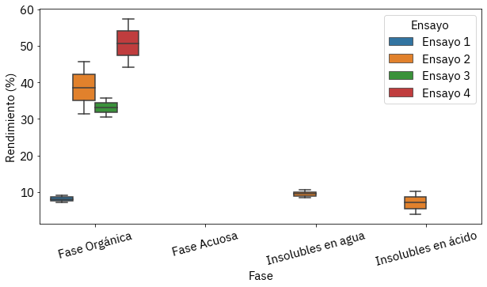

```python
# Gráfico de los rendimientos y pureza según prueba y fase, para los gráficos de pureza se descartan
#   las filas de Fase Acuosa ya que no corresponden

fig = plt.figure()

def box_graph(df, key):
    sns.boxplot(x='Fase',y=key, data=data, hue='Ensayo')
    plt.ylabel('Rendimiento (%)')
    plt.xticks(rotation=15)
    plt.show()

box_graph(df,'Pureza')
```

```python
# Redondeo los valores de cantidad total de AC
# Agrupo la data por Prueba y Fase, redondeo a tres decimales y exporto a un Excel

df['Cantidad AC (g)'] = np.round(df['Cantidad AC (g)'].astype('float'), 3)
group = df[['Cantidad AC (g)','Fase','Rendimiento','Pureza']].reset_index().groupby(['Ensayo','Fase'])
group = np.round(group.agg([np.mean,np.std]), decimals=2)
group = group.replace(np.nan, '---')
```

```python
# Yapa: generar tabla de desviaciones

# Del nuevo DataFrame extraigo las columnas que quiero utilizar
columnas_de_interes = [i for (i,y) in group.columns.to_list()[::2]]

# Defino un nuevo Dataframe vacío, con las columnas definidas
#  como las columnas de interés
means = pd.DataFrame(columns = columnas_de_interes)

for column in columnas_de_interes:
    # Al nuevo DataFrame le asigna valores de
    means[column] = group[(column, 'mean')].astype('str') + ' ± '  +  group[(column, 'std')].astype('str')

means
```

| Ensayo | Fase | Cantidad AC (g) | Rendimiento | Pureza |
| --- | --- | --- | --- | --- |
| Ensayo 1 | Extracto | 0.16 ± 0.01 | --- ± --- | --- ± --- |
|  | Fase Acuosa | 0.0 ± 0.0 | 1.51 ± 1.23 | --- ± --- |
|  | Fase Orgánica | 0.01 ± 0.0 | 6.92 ± 1.16 | 8.08 ± 1.49 |
| Ensayo 2 | Extracto | 0.17 ± 0.03 | --- ± --- | --- ± --- |
|  | Fase Acuosa | 0.0 ± 0.0 | 0.78 ± 0.01 | --- ± --- |
|  | Fase Orgánica | 0.04 ± 0.01 | 24.79 ± 0.83 | 38.54 ± 10.03 |
|  | Insolubles en agua | 0.02 ± 0.01 | 9.66 ± 5.66 | 9.44 ± 1.57 |
|  | Insolubles en ácido | 0.01 ± 0.0 | 5.2 ± 2.12 | 7.06 ± 4.43 |
| Ensayo 3 | Extracto | 0.26 ± 0.02 | --- ± --- | --- ± --- |
|  | Fase Acuosa | 0.01 ± 0.0 | 2.51 ± 0.96 | --- ± --- |
|  | Fase Orgánica | 0.12 ± 0.02 | 44.53 ± 10.84 | 33.15 ± 3.6 |
| Ensayo 4 | Extracto | 0.97 ± 0.08 | --- ± --- | --- ± --- |
|  | Fase Acuosa | 0.02 ± 0.0 | 2.07 ± 0.18 | --- ± --- |
|  | Fase Orgánica | 0.62 ± 0.21 | 63.49 ± 16.59 | 50.73 ± 9.46 |